# Data_Analysis_Salenetri

Mia Salenetri

11/4/2019

## R Markdown

```r
#install.packages("tidycensus")
#install.packages("arcos")
#install.packages("tidyverse")
#install.packages("janitor")
#install.packages("scales")
#install.packages("ggrepel")
#install.packages("ggalt")
#install.packages("ggfortify")
#install.packages("gapminder")
```

```r
library(tidyverse)
library(tidycensus)
library(arcos)
library(janitor)
library(scales)
library(ggrepel)
library(ggthemes)
```

```r
library(dplyr)
options(scipen = 0)
library(ggplot2)
library(ggalt)
library(ggfortify)
library(gapminder)
```

```r
opioid_deaths_06_12 <- read_tsv("opioid_deaths_06_12.txt")
ruralurbancodes2013 <- read_csv("ruralurbancodes2013.csv")
ARCOSkey <- "uO4EK6I"
```

Using the nine rural/urban population groups determined by the USDA, I want to determine whether different demographic groups are affected differently based on the size of a metro area.

First, I want to import the datasets I’ll need: - ARCOS pills per person per county - the USDA rural urban county codes and populations (done) - the opioid death rates by county (done) - Census demographic data by county for race/ethnicity and economic class

```r
options(scipen=999)

#set CENSUSkey
census_api_key("549950d36c22ff16455fe196bbbd01d63cfbe6cf")
```

```
## To install your API key for use in future sessions, run this function with `install = TRUE`.
```

```r
acs_variables <- load_variables(2017, "acs5", cache = FALSE)

#load census data
county_geodata <- get_acs(geography = "county",
              variables = "B01001_001", geometry = TRUE)
county_geodata_shifted <- get_acs(geography = "county",
              variables = "B01001_001", geometry = TRUE, shift_geo = TRUE)
```

```
## Using feature geometry obtained from the albersusa package
```

```
## Please note: Alaska and Hawaii are being shifted and are not to scale.
```

```r
state_geodata <- get_acs(geography = "state",
              variables = "B01001_001", geometry = TRUE)
state_geodata_shifted <- get_acs(geography = "state",
              variables = "B01001_001", geometry = TRUE, shift_geo = TRUE)
```

```
## Using feature geometry obtained from the albersusa package
```

```
## Please note: Alaska and Hawaii are being shifted and are not to scale.
```

```r
median_income <- get_acs(geography = "county",
              variables = "B25099_001", geometry = TRUE, shift_geo = TRUE)
```

```
## Using feature geometry obtained from the albersusa package
```

```
## Please note: Alaska and Hawaii are being shifted and are not to scale.
```

```r
race_by_county <- get_acs(geography = "county",
              variables = "B02001_001", geometry = TRUE, shift_geo = TRUE)
```

```
## Using feature geometry obtained from the albersusa package
```

```
## Please note: Alaska and Hawaii are being shifted and are not to scale.
```

Instead of working with the differences by year, I want to just use the averages across 2006-12. This means I’ll need to alter the ARCOS dataset to show the average amount of pills per person from 2006-12 and the total opioid deaths from 2006-12 by county. Before I’ve done any work I’ve noticed that a lot of inputs for “deaths” in opioid_deaths_06_12 are “suppressed.” I’m not sure what this means but I assume that I won’t have death data for every county. In the end though, I think this won’t be an issue as I can use the trends from the counties I do have data for to make an educated guess/inference about that size of metro center.

```r
#total number of pills from 2006-2012 categorized by the countyfips code:
arcos_county_pills_per_year <- summarized_county_annual(key = ARCOSkey) %>%
  clean_names()

arcos_county_totals <- arcos_county_pills_per_year %>%
  group_by(countyfips) %>%
  summarise(avg_pills_year = mean(dosage_unit))
```

Join the newly simplified arcos_county_totals with the ruralurbancodes2013 into new rural_urban_working. It will now contain the countyfips, state, county name, population, urban group and pill totals.

```r
#changing column names and removing unnecessary columns
rural_urban_working <- ruralurbancodes2013 %>%
  mutate(countyfips = FIPS) %>%
  select(-FIPS) %>%
  select(-Description) %>%
  select(-X7) %>%
  select(-X8)

#joining the two tables
rural_urban_working <- rural_urban_working %>%
  inner_join(arcos_county_totals, by = NULL, copy = FALSE)
#adding pills per person column
rural_urban_working <- rural_urban_working %>%
  mutate(Pills_per_person = avg_pills_year/ Population_2010 )
```

I want to attempt to condense the rural_urban_working data and get summaries for the entire group of nine The two more rural groups and one most urban have the lowest rates of pills per person.

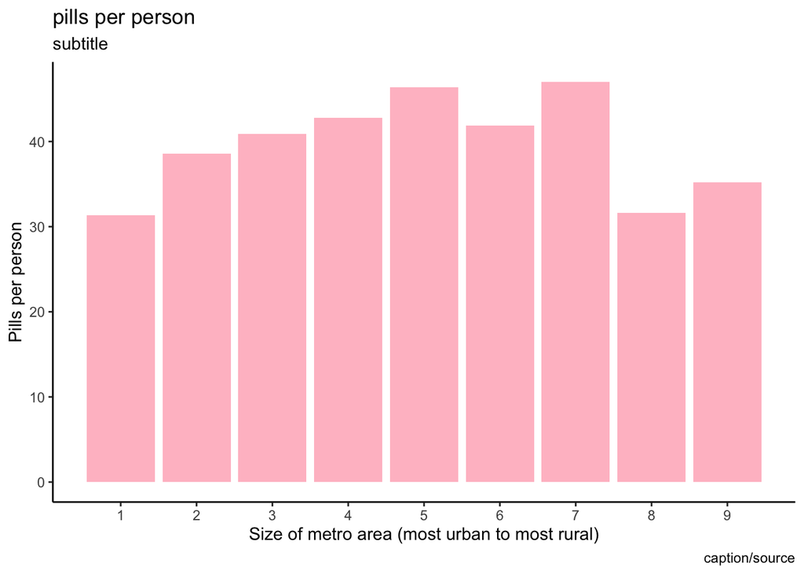

```r
rural_urban_condensed <- rural_urban_working %>%
  group_by(RUCC_2013) %>%
  summarise(avg_pills_year=sum(avg_pills_year),
            Total_population=sum(Population_2010)) %>%
  mutate(Pills_per_person = avg_pills_year/ Total_population)

#chart, comparing urbanness/ruralness to pills per person
ggplot(rural_urban_condensed) +
  geom_bar(stat="identity", aes(RUCC_2013, Pills_per_person), fill="pink") +
  labs(x="Size of metro area (most urban to most rural)", y="Pills per person", title="pills per person", subtitle = "subtitle", caption = "caption/source") +
  theme(axis.text.x = element_text(angle = 45, hjust = 1))+
  scale_y_continuous(labels = comma)+
  theme_classic()+
  scale_x_continuous(breaks = c(1,2,3,4,5,6,7,8,9))
```

Now, join the census demographic dataset and the USDA population/metro size dataset. Instead of looking at the racial makeup and socioeconomic class for each county, I want to use the median incomes and racial makeups by size of metro area. For example, I want to say that the median household income for a county in a nonmetro area with an urban population of 20,000 or more is X.

```r
#median_income <- median_income %>%
#  rename(countyfips = GEOID) %>%
#  select(-variable)

#big_data <- big_data %>%
#  inner_join(median_income, by = NULL, copy = FALSE)

#big_data <- big_data %>%
#  rename(med_income = estimate)
#join census demographics with USDA population and metro area group
```

While I won’t be able to open it on my personal computer, I want to have a massive dataset that is a combination of all the data I could ever need

```r
#combine arcos data with USDA (county, state, fips, population, pills/person, rural/urban rank)
big_data <- rural_urban_working %>%
  group_by(countyfips)


#then add the demographics for each county (race/ethnicity and median income)
#then add optoid deaths for each county
```